# JOUR8500 Week 04 LIWC and Hugging Face API Demo Problem Set (In Class)

Carolina Aguiar, Isabel Garlough-Shah, and Anastasia Micich

2026-02-09

## Overview

This problem set introduces the software “LIWC” (pronounced “Luke”) and Hugging Face API.

In part 1 we will overview the LIWC software and primary features, how to upload user generated dictionaries into LIWC, analyze a Redditt data set on depression in LIWC, and work through descriptive analysis of a complete CSV LIWC file.

## LIWC

### Part 1.1: LIWC software

LIWC-22 (Linguistic Inquiry and Word Count) is a text analysis program used to quantify psychological, emotional, and structural features of language. Researchers commonly use LIWC to analyze open-ended survey responses, social media posts, interviews, and other text data to understand patterns in how people communicate.

In this demo, we will explore how LIWC-22 works using the Desktop app. To download the Desktop app click here: [LIWC-22.app](https://www.liwc.app/download/dl-select)

Download the application based on your OS or Platform system. From here input the Serial Number: “LIWC22-ED9FB079-8ED94179-9F5D63C2-75DE33EC” to access LIWC until **Saturday, March 7th, 2026**

### Part 1.2: Exploring base LIWC Dictionaries

One of the most important features of LIWC-22 is the dictionaries tab. You can find the dictionaries available in the base verison of LIWC-22 in the second tab under LIWC analysis section.

[figure not shown]

- Here, you can:
  - View the default LIWC-22 dictionary categories
  - See how words are grouped into psychological and linguistic constructs
  - Explore specialized dictionaries (e.g., emotion, cognition, social processes)
- This is where the core logic of LIWC lives — the dictionaries determine how text is classified so it is important to understand what aspects or kind of text dictionaries analyze to ensure that is your intended operationalization as well.

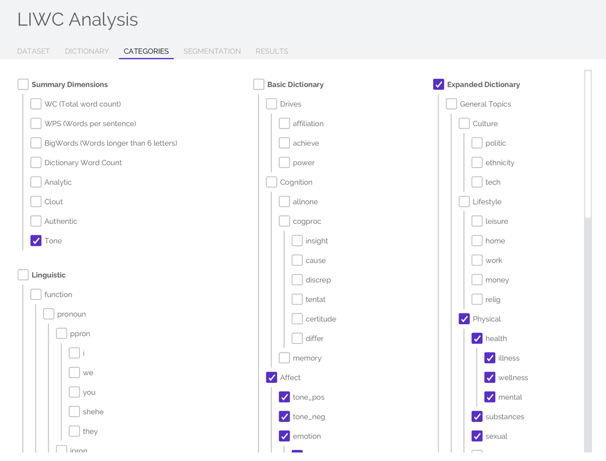

- A new feature of LIWC-22 is multilingual support.
  - LIWC now includes validated dictionaries for multiple languages, allowing researchers to analyze text data beyond English. This is especially useful for cross-cultural research, international datasets, and multilingual social media content.
  - You can select different language dictionaries directly within the interface before running your analysis.

[figure not shown]

### Part 1.3: Uploading User-Created LIWC Dictionaries

In addition to the built-in LIWC dictionaries, LIWC-22 allows researchers to upload their own custom dictionaries. This is useful when you want to analyze text using categories or languages that are specific to your research project, population, or theory. To explore the User-Created LIWC Dictionaries click here: [User Created Dictionaries](https://www.liwc.app/dictionaries/dict-user)

[figure not shown]

### Part 1.4: Analyzing data in LIWC

To begin analyzing a data set in LIWC, you need to upload a clean CSV file. This means that the CSV file should only contain text; no content analysis data, images, links. Furthermore, for social media data in particular, you should remove hashtags within text so that LIWC can properly run, and check for spelling errors and formatting issues so that LIWC can properly evaluate text data.

[figure not shown]

In our analysis we will run the [depression_dataset_reddit_cleaned.csv](https://www.kaggle.com/datasets/infamouscoder/depression-reddit-cleaned) and use the User-Created dictionary entitled [“Stress Dictionary” by Wei Wang et al.](https://www.liwc.app/dictionaries/dict-user)

After uploading the [depression_dataset_reddit_cleaned.csv](https://www.kaggle.com/datasets/infamouscoder/depression-reddit-cleaned) in LIWC you will use the check box to designate which column will be used for analysis.

After this you will go to the Dictionary tab and designate which dictionaries you want to run. For this analysis run “LIWC-22 Dictionary (English)” and “stress-dictionary.dicx”.

In the categories section you can choose specific elements you want to analyze. Once you’ve finalized your categories click the `RUN LIWC` button in the bottom right corner.

### Problem Set 1: Cleaning data and descriptive analysis of LIWC data in R

First in this problem set we need to load in the program `dplyr` and the CSV files from LIWC using the `read.csv("[Name_of_file]", stringsAsFactors = FALSE).` and investigate column names.

Let’s say we want to get rid of the `Segment` column because all the values are 1 and we want a cleaner data set.

- First what would we do to confirm that all the rows are filled with 1?
- Second, what would we do to remove the `Segment` column?

In LIWC data is displayed as numerical, but it is meant to represent the average percentage of words appearing in the overall text. If we wanted to change the numeric into a decimal to better represent the data what are two ways to change the data set?

To understand the average stress, affect, mental, and death language percentage within Reddit posts discussing depression you would use which code?

## Hugging Face API

### Part 2.1: What even is an API?

An API (Application Programming Interface) is used for one program to talk to another program over the internet.

Instead of downloading a large machine-learning model to your computer, you can send text to a company’s server and ask their model to analyze it for you. The server runs the model and sends the results back to R.

In this demo, we use the Hugging Face Inference API to send text to a pre-trained language model and receive percentages on particular language dimensions.

### Part 2.1: What is Hugging Face API?

Hugging Face is a platform where those who work on machine learning collaborates on models, data sets, and applications. It provides a well-organized library of machine learning models that other people have already trained.

The Hugging Face Inference API allows you to use those models directly from your own code without needing to download them, train them, or host them yourself.

### Part 2.2: Installing Hugging Face API into R

To connect R to the Hugging Face Inference API, we first need to install and load in your library two packages that allow R to communicate with web-based services. These packages are entitled `httr2` and `jsonlite`. Once installed, these packages allow R to send text to Hugging Face’s servers and receive model predictions back in a format you can easily work with.

### Part 2.3: Retrieving and installing Hugging Face API token in R

- Create a free account at [Hugging Face](https://huggingface.co)
- Go to [Settings > Access Tokens](https://huggingface.co/settings/tokens)
- Create a new token (read access is sufficient for inference)
- Once you’ve created a token, use the code `Sys.setenv(HF_API_TOKEN = "[API Token]"` to install your Hugging Face API to R
  - For this problem set use the token `"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"`

For future coding to check that this token is saved as an environmental variable in your computer use the code `Sys.getenv("HF_API_TOKEN")`. This code retrieves your Hugging Face API token from your computer’s environment variables rather than hard-coding it directly into the script. This will keep authentication credentials and API keys secure and separate from your code if you are sharing R scripts.

### Problem Set 2: Hugging API Sentiment Analyis

#### Step 1: Loading sentiment analysis and single sentence evaluation

To run analysis using Hugging API. This code defines a reusable R function, `multilingual_sentiment()`, that sends text from R to a Hugging Face sentiment analysis model. The function begins by creating an object labeled `multilingual_sentiment` and beginning the code with `function(text) {`. Within the brace retrieve the `Sys.getenv("HF_API_TOKEN")`.

Then use the `POST("https://router.huggingface.co/hf-inference/models/cardiffnlp/twitter-roberta-base-sentiment-latest",` function from `httr package` to send the input text from the sentiment model. In the next three lines `add_headers(Authorization = paste("Bearer", hf_token)),` `encode = "json",` `body = list(inputs = text)` and end the function with a closing bracket.

Then add the `Sys.sleep(1.1)` code to pause execution briefly to prevent exceeding the API’s rate limits. In the next line use the function called `stop_for_status(res)` to ensure that any HTTP errors are caught immediately. After this create a `txt` object for this line of code `content(res, as = "text", encoding = "UTF-8")`. In the final line use the code `fromJSON(txt)[[1]]` to extract the plain text to prepare it for the sentiment model.

Next try evaluating sentences like “I like you” or “te amo” in the `multilingual_sentiment()` you created.

#### Step 2: Evaluate a whole CSV file.

Now lets say you have a whole CSV data set you want to analyze. For the purpose of this problem set use the `LIWC2015 Results (Isa_SelfCare) (1).csv` in the [[Week 4] Computational Toolkit Demo](https://canvas.umn.edu/courses/537884/discussion_topics/3363516). In the next line load in the CSV file and with an object create a shorter name.

Next you will run a similar set of code in Step 1. Instead you will add `function(text, max_chars = 4000)` to set a limit on evaluation character count. Below the `Sys.getenv("HF_API_TOKEN")` you will add `text <- as.character(text)`, `text <- enc2utf8(text)`, `text <- gsub("[[:cntrl:]]", " ", text)`, `text <- trimws(text)` and `if (nchar(text) > max_chars) text <- substr(text, 1, max_chars)`. Finally after the `Sys.sleep(1.1)` code in the next line add `if (http_error(res)) return(list(label = NA_character_, score = NA_real_))`.

Next load in `dplyr` and `tidyr` to run the sentiment analysis in the `LIWC2015 Results (Isa_SelfCare) (1).csv`.

After loading in the CSV create a pipe (`%>%`) and in the next line use the `rowwise() %>%` command ensures the function runs once for each individual text entry rather than across the whole column at once. Next use the `mutate(sentiment = list(multilingual_sentiment(Source))) %>%` code to run the sentiment analysis on each text entry and turns the result into real columns in the data set. Finally use `unnest_wider(sentiment)` and check out your updated `LIWC2015 Results (Isa_SelfCare) (1).csv`data set

### Other Notes

- Here is a video tutorial on the basics of LIWC-22 if you have any additional questions [LIWC-22 2022 Tutorial 1: Getting started with LIWC-22](https://www.youtube.com/watch?v=IGBI8LnYGNs&t=125s)